# Homework 2

Mehmet Akif Taşcıoğlu

25 04 2021

# Introduction

Housing is one of the most important necessity of human beings. Probably a majority of people sell or buy a residential property at least once in a lifetime.Therefore,housing market is obviously enormous.In this homework, the data of the number of house sales (total) in Turkey is fitted using linear regression.Different relevant data series and other components such as trend and monthly seasonal dummy variables are used for fitting the data in a linear regression model.The total number of house sales can be affected by various economic factors.All data are monthly and taken from Electronic Data Delivery System of the TCMB.The time interval of interest is January 2015-March 2021.My aim is to provide a forecast of 2021-04.

# Data Analysis

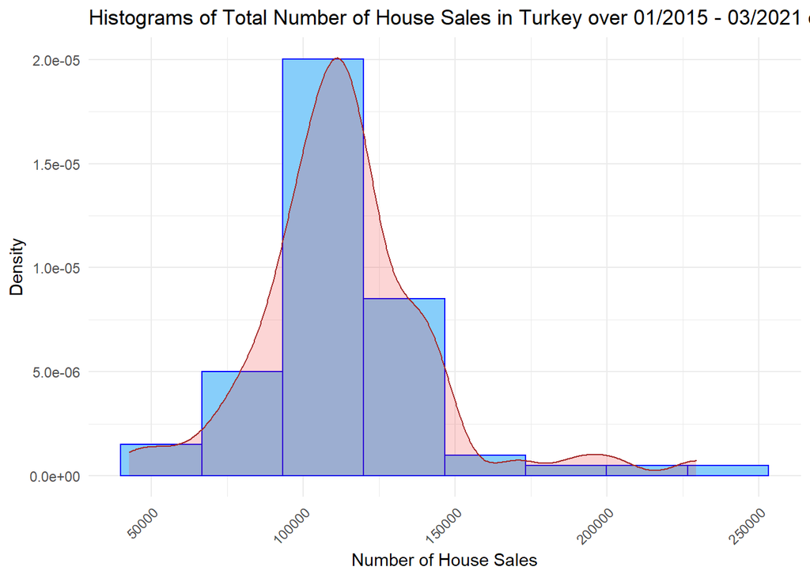

The histogram reveals that the monthly number of house sales seem to be distributed similar to a normal distribution.

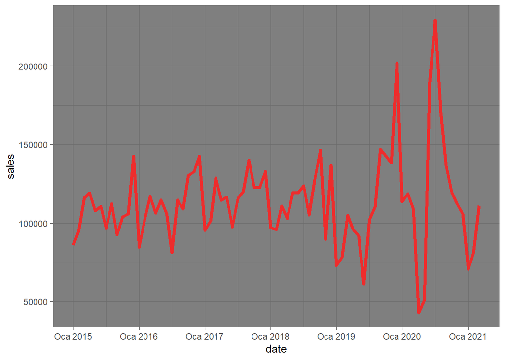

First of all,there isn’t an up trend or down trend throughout 6 year.So,the Trend component most probably will be a non-significant predictor.Fluctuations occurred within each year, while fluctuating within a certain narrow band until 2019, the amplitude of the fluctuations increased a lot after 2019.Moreover, January data is almost always low,and December data is almost always high.This means that there is some kind of seasonality in our data, and it should be included in our model using monthly seasonal dummy variables.In the middle of 2016, there is a sudden drop because of Turkish coup attempt.In addition to these,great deviations can be seen after March 2020 due to the COVID-19.

# Setting Up Linear Regression Model

```r
house[,trend:=1:.N]
house_reg=lm(sales~trend,house)
summary(house_reg)
```

```
##
## Call:
## lm(formula = sales ~ trend, data = house)
##
## Residuals:
##    Min     1Q Median     3Q    Max
## -75711 -14293  -1627  10924 110308
##
## Coefficients:
##             Estimate Std. Error t value Pr(>|t|)
## (Intercept) 106662.6     6852.2   15.57   <2e-16 ***
## trend          184.9      156.7    1.18    0.242
## ---
## Signif. codes:  0 '***' 0.001 '**' 0.01 '*' 0.05 '.' 0.1 ' ' 1
##
## Residual standard error: 29370 on 73 degrees of freedom
## Multiple R-squared:  0.01871,    Adjusted R-squared:  0.005273
## F-statistic: 1.392 on 1 and 73 DF,  p-value: 0.2419
```

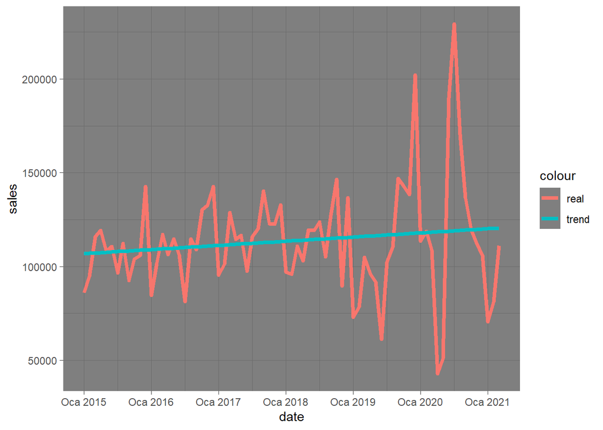

```r
house[,trend_constant:=predict(house_reg,house)]
ggplot(house,aes(x=date))+geom_line(aes(y=sales,color='real'),size=1.5)+geom_line(aes(y=trend_constant,color='trend'),size=1.5)+ theme_dark()
```

```r
house[,mon:=as.character(month(date,label=T))]
house_reg2=lm(sales~trend+mon,house)
summary(house_reg2)
```

```
##
## Call:
## lm(formula = sales ~ trend + mon, data = house)
##
## Residuals:
##    Min     1Q Median     3Q    Max
## -58306 -11505   -128  11730 100398
##
## Coefficients:
##             Estimate Std. Error t value Pr(>|t|)
## (Intercept) 117083.2    12360.8   9.472 1.16e-13 ***
## trend          136.0      145.3   0.936   0.3527
## monAra       21067.9    15651.5   1.346   0.1832
## monEki        5171.6    15643.4   0.331   0.7421
## monEyl        3057.5    15641.3   0.195   0.8457
## monHaz       -7779.5    15643.4  -0.497   0.6207
## monKas       -5680.7    15646.7  -0.363   0.7178
## monMar       -8385.2    15072.4  -0.556   0.5800
## monMay      -21548.3    15646.7  -1.377   0.1734
## monNis      -24699.2    15651.5  -1.578   0.1196
## monOca      -33506.0    15072.4  -2.223   0.0299 *
## monŞub      -26170.6    15071.7  -1.736   0.0875 .
## monTem        2762.7    15641.3   0.177   0.8604
## ---
## Signif. codes:  0 '***' 0.001 '**' 0.01 '*' 0.05 '.' 0.1 ' ' 1
##
## Residual standard error: 27090 on 62 degrees of freedom
## Multiple R-squared:  0.2912, Adjusted R-squared:  0.154
## F-statistic: 2.122 on 12 and 62 DF,  p-value: 0.02792
```

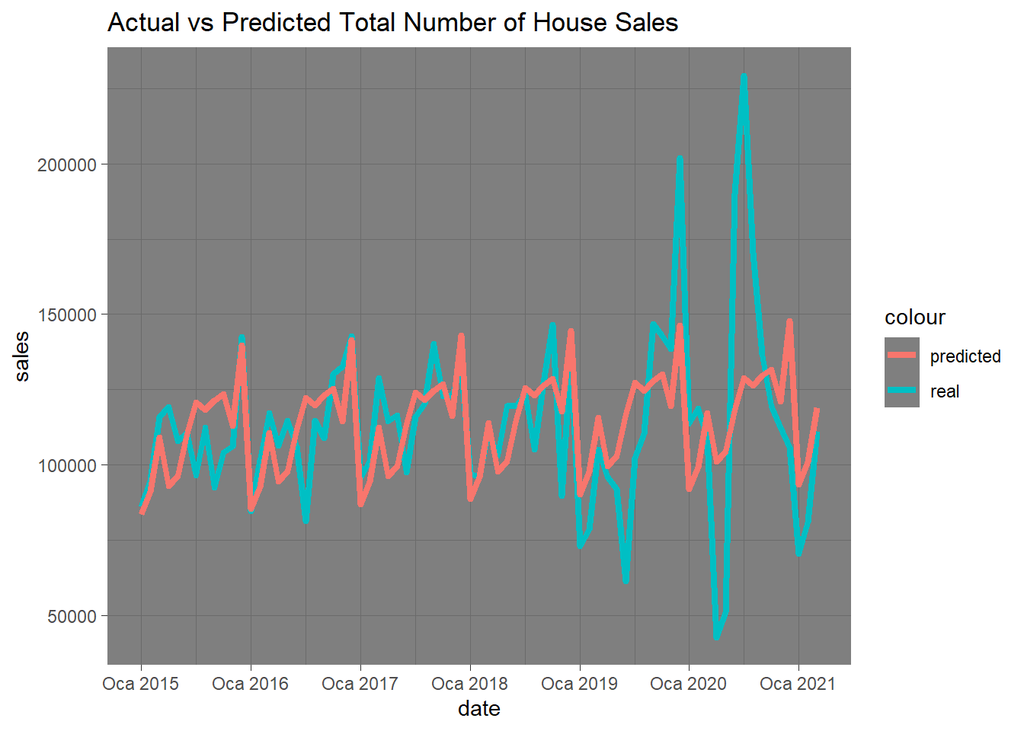

```r
house[,trend_constant_monthly_seas:=predict(house_reg2,house)]
ggplot(house,aes(x=date))+geom_line(aes(y=sales,color='real'),size=1.5)+geom_line(aes(y=trend_constant_monthly_seas,color='predicted'),size=1.5)+ theme_dark()+labs(title = "Actual vs Predicted Total Number of House Sales")
```

## Adding New Variables

### Adding housing loan interest rate as a predictor

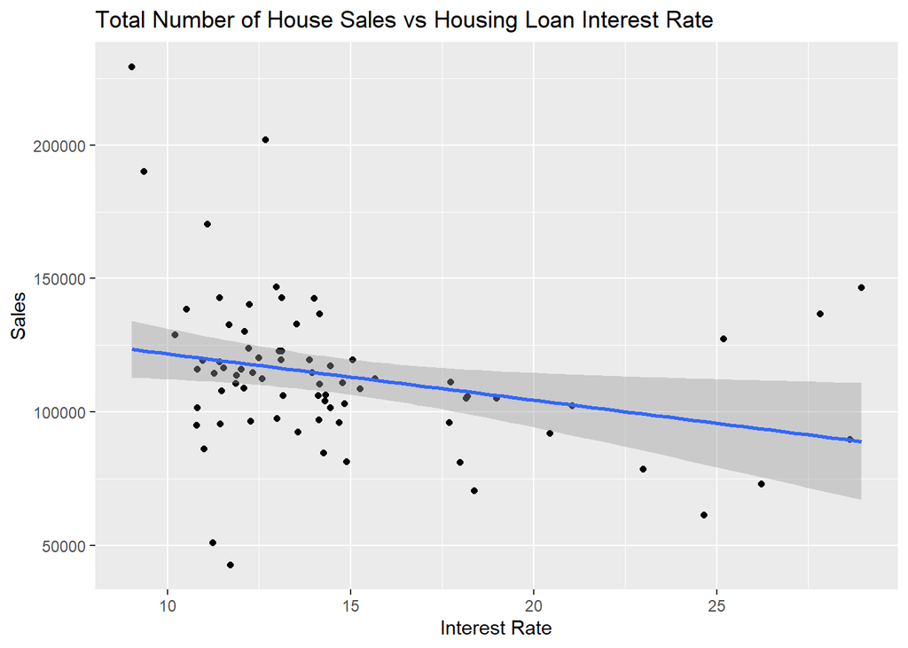

```r
interestrate<-read_excel("C:/Users/User/Desktop/ie360/HousingLoanInterestRate.xlsx")
ggplot(house,aes(x=interestrate$faiz,y=sales))+geom_point()+geom_smooth(method = lm)+labs(title = "Total Number of House Sales vs Housing Loan Interest Rate", y = "Sales", x = "Interest Rate")
```

### Correlation between target variable and Housing Loan Interest Rate

```r
cor(house$sales,interestrate$faiz)
```

```
## [1] -0.266015
```

```r
house[,faiz:=interestrate$faiz]
house_reg3=lm(sales~trend+mon+faiz,house)
summary(house_reg3)
```

```
##
## Call:
## lm(formula = sales ~ trend + mon + faiz, data = house)
##
## Residuals:
##    Min     1Q Median     3Q    Max
## -67138  -9696   -254   9566  84562
##
## Coefficients:
##             Estimate Std. Error t value Pr(>|t|)
## (Intercept) 145303.2    13651.7  10.644 1.55e-15 ***
## trend          285.3      138.7   2.058 0.043915 *
## monAra       27125.5    14376.8   1.887 0.063955 .
## monEki       11087.6    14365.1   0.772 0.443187
## monEyl        6472.4    14302.8   0.453 0.652494
## monHaz       -6034.3    14282.3  -0.423 0.674144
## monKas       -1089.1    14332.2  -0.076 0.939678
## monMar       -6328.3    13764.8  -0.460 0.647332
## monMay      -20714.3    14279.2  -1.451 0.151998
## monNis      -24437.4    14281.9  -1.711 0.092148 .
## monOca      -29039.6    13807.1  -2.103 0.039578 *
## monŞub      -23359.3    13774.1  -1.696 0.095006 .
## monTem        2848.9    14272.5   0.200 0.842454
## faiz         -2491.3      679.0  -3.669 0.000513 ***
## ---
## Signif. codes:  0 '***' 0.001 '**' 0.01 '*' 0.05 '.' 0.1 ' ' 1
##
## Residual standard error: 24720 on 61 degrees of freedom
## Multiple R-squared:  0.4193, Adjusted R-squared:  0.2956
## F-statistic: 3.388 on 13 and 61 DF,  p-value: 0.0006029
```

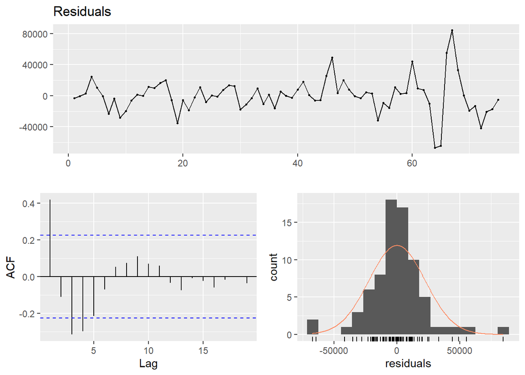

```r
checkresiduals(house_reg3$residuals)
```

### Adding Dollar Exchange Rate as a predictor

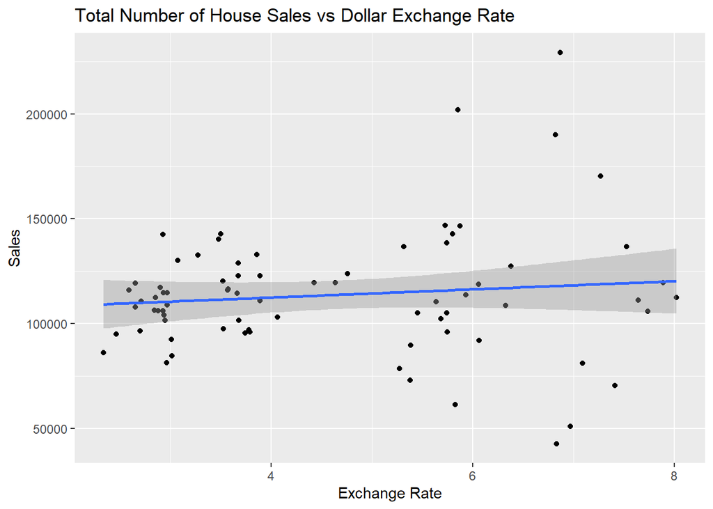

```r
dolar<-read_excel("C:/Users/User/Desktop/ie360/DollarExchangeRate.xlsx")
ggplot(house,aes(x=dolar$kur,y=sales))+geom_point()+geom_smooth(method = lm)+labs(title = "Total Number of House Sales vs Dollar Exchange Rate", y = "Sales", x = "Exchange Rate")
```

### Correlation between target variable and Dollar Exchange Rate

```r
cor(house$sales,dolar$kur)
```

```
## [1] 0.1102687
```

### Adding ‘Probability of Borrowing Money’ as a predictor

This variable shows the probability of borrowing money for basic necessities of people who participated in this survey.Borrowing for basic needs shows that people cannot meet even their basic needs .It is not possible for people to buy a house during such economic difficulties.Therefore,there will be a negative correlation between them.

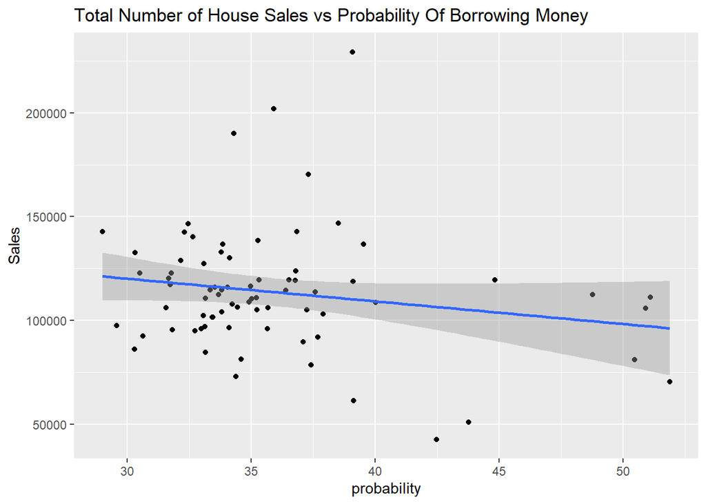

```r
borrow<-read_excel("C:/Users/User/Desktop/ie360/ProbOfBorrowingMoney.xlsx")
ggplot(house,aes(x=borrow$probability,y=sales))+geom_point()+geom_smooth(method = lm)+labs(title = "Total Number of House Sales vs Probability Of Borrowing Money", y = "Sales", x = "probability")
```

### Correlation between target variable and Probability of Borrowing Money

```r
cor(house$sales,borrow$probability)
```

```
## [1] -0.1841362
```

```r
house[,prob:=borrow$probability]
house[,kur:=dolar$kur]
house_reg4=lm(sales~mon+faiz+prob+kur,house)
summary(house_reg4)
```

```
##
## Call:
## lm(formula = sales ~ mon + faiz + prob + kur, data = house)
##
## Residuals:
##    Min     1Q Median     3Q    Max
## -68935  -9641    534   8801  77177
##
## Coefficients:
##             Estimate Std. Error t value Pr(>|t|)
## (Intercept) 220291.0    24857.6   8.862 1.69e-12 ***
## monAra       30712.7    13117.0   2.341 0.022548 *
## monEki       12920.9    13088.9   0.987 0.327526
## monEyl        5575.8    13023.1   0.428 0.670078
## monHaz       -4444.5    13015.2  -0.341 0.733929
## monKas         811.9    13057.3   0.062 0.950628
## monMar        1772.8    12698.4   0.140 0.889439
## monMay      -12782.8    13171.1  -0.971 0.335682
## monNis      -15175.7    13229.4  -1.147 0.255884
## monOca      -23124.3    12666.1  -1.826 0.072875 .
## monŞub      -12360.3    12842.3  -0.962 0.339678
## monTem        6467.9    13025.9   0.497 0.621328
## faiz         -2839.8      633.9  -4.480 3.42e-05 ***
## prob         -3172.6      837.0  -3.791 0.000351 ***
## kur          10930.9     2582.9   4.232 8.06e-05 ***
## ---
## Signif. codes:  0 '***' 0.001 '**' 0.01 '*' 0.05 '.' 0.1 ' ' 1
##
## Residual standard error: 22510 on 60 degrees of freedom
## Multiple R-squared:  0.5265, Adjusted R-squared:  0.416
## F-statistic: 4.765 on 14 and 60 DF,  p-value: 9.064e-06
```

### Adding ‘Probability of Buying Home’ as a predictor

In Central Bank of the Republic of Turkey’s (CBRT) database, Probability of Buying Home can be obtained under the tab “Surveys”.This variable shows how percentage of the people surveyed had the idea of buying a home.

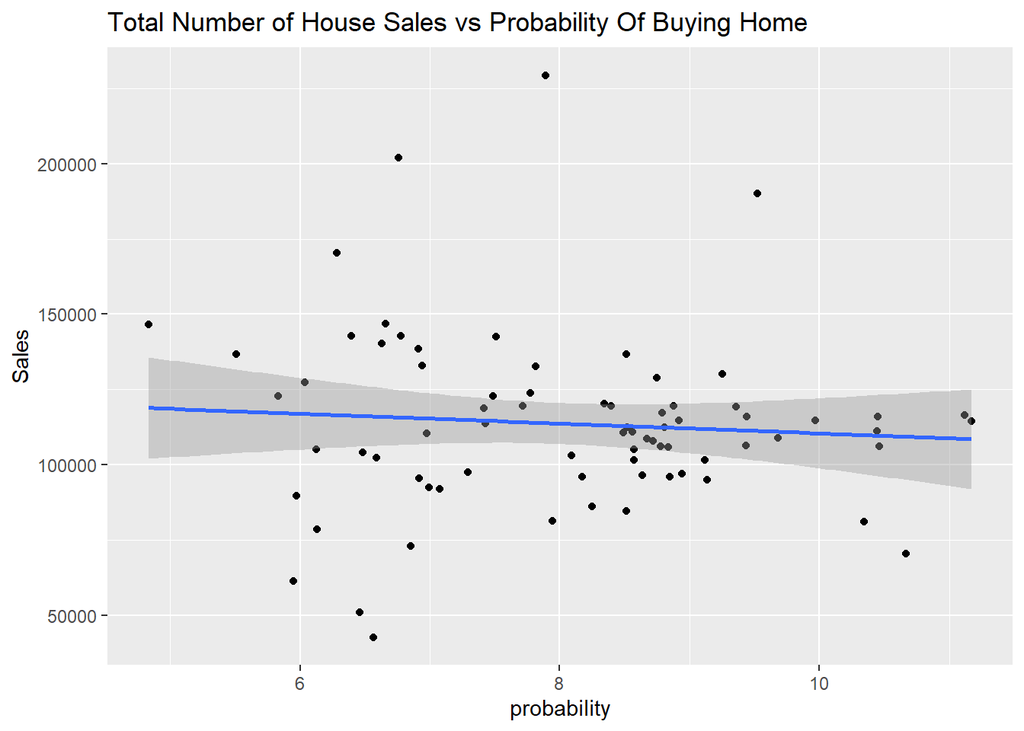

```r
buying<-read_excel("C:/Users/User/Desktop/ie360/ProbOfBuyingHomeSurvey.xlsx")
ggplot(house,aes(x=buying$probability,y=sales))+geom_point()+geom_smooth(method = lm)+labs(title = "Total Number of House Sales vs Probability Of Buying Home", y = "Sales", x = "probability")
```

### Correlation between target variable and Probability of Buying Home

```r
cor(house$sales,buying$probability)
```

```
## [1] -0.07872816
```

Correlation value between them is very low so it isn’t good predictor.

### Adding Gold Price as a predictor

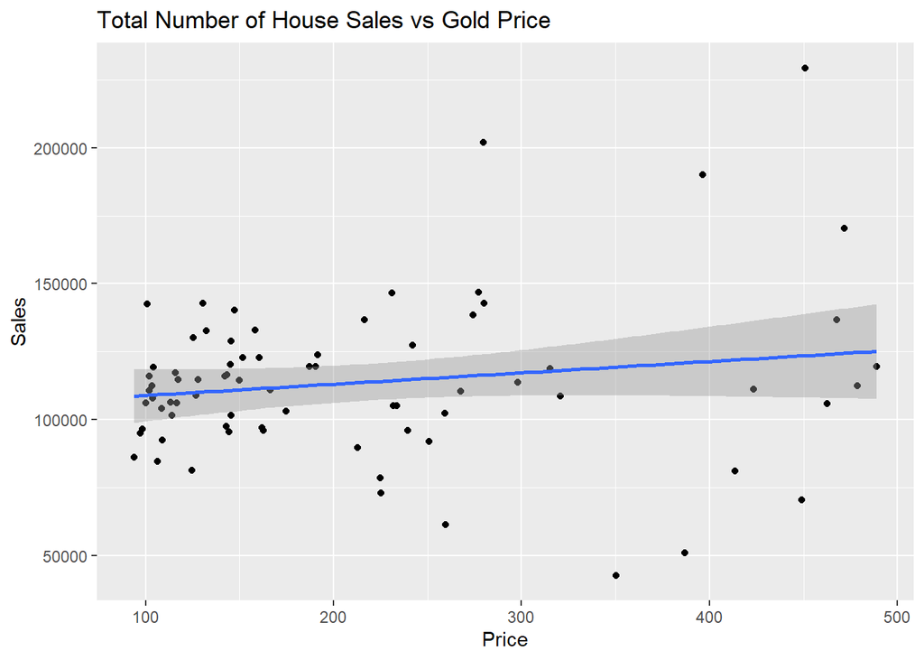

```r
gold<-read_excel("C:/Users/User/Desktop/ie360/goldprice.xlsx")
ggplot(house,aes(x=gold$price,y=sales))+geom_point()+geom_smooth(method = lm)+labs(title = "Total Number of House Sales vs Gold Price ", y = "Sales", x = "Price")
```

### Correlation between target variable and Gold Price

```r
cor(house$sales,gold$price)
```

```
## [1] 0.1636994
```

```r
house[,altın:=gold$price]
house_reg5=lm(sales~mon+faiz+prob+kur+altın,house)
summary(house_reg5)
```

```
##
## Call:
## lm(formula = sales ~ mon + faiz + prob + kur + altın, data = house)
##
## Residuals:
##    Min     1Q Median     3Q    Max
## -61678 -10191   1745   8646  61796
##
## Coefficients:
##             Estimate Std. Error t value Pr(>|t|)
## (Intercept) 260389.0    29627.0   8.789 2.57e-12 ***
## monAra       32225.9    12684.5   2.541   0.0137 *
## monEki       12672.8    12640.9   1.003   0.3202
## monEyl        6151.8    12579.3   0.489   0.6266
## monHaz       -3284.4    12579.2  -0.261   0.7949
## monKas        2282.2    12626.0   0.181   0.8572
## monMar        5583.2    12373.8   0.451   0.6535
## monMay       -7198.4    12947.6  -0.556   0.5803
## monNis       -8799.0    13071.0  -0.673   0.5035
## monOca      -22742.3    12233.2  -1.859   0.0680 .
## monŞub      -10162.2    12438.7  -0.817   0.4172
## monTem        6573.6    12579.6   0.523   0.6032
## faiz         -1564.1      824.6  -1.897   0.0627 .
## prob         -4281.4      940.1  -4.554 2.69e-05 ***
## kur          -7122.4     8205.7  -0.868   0.3889
## altın          290.4      125.7   2.309   0.0244 *
## ---
## Signif. codes:  0 '***' 0.001 '**' 0.01 '*' 0.05 '.' 0.1 ' ' 1
##
## Residual standard error: 21740 on 59 degrees of freedom
## Multiple R-squared:  0.5657, Adjusted R-squared:  0.4553
## F-statistic: 5.124 on 15 and 59 DF,  p-value: 2.485e-06
```

### Adding Survey Data as a predictor

The Survey question is ‘How has your business situation developed over the past 3 months?’.Survey results will give us the business statement over the past three months of people who own a business .

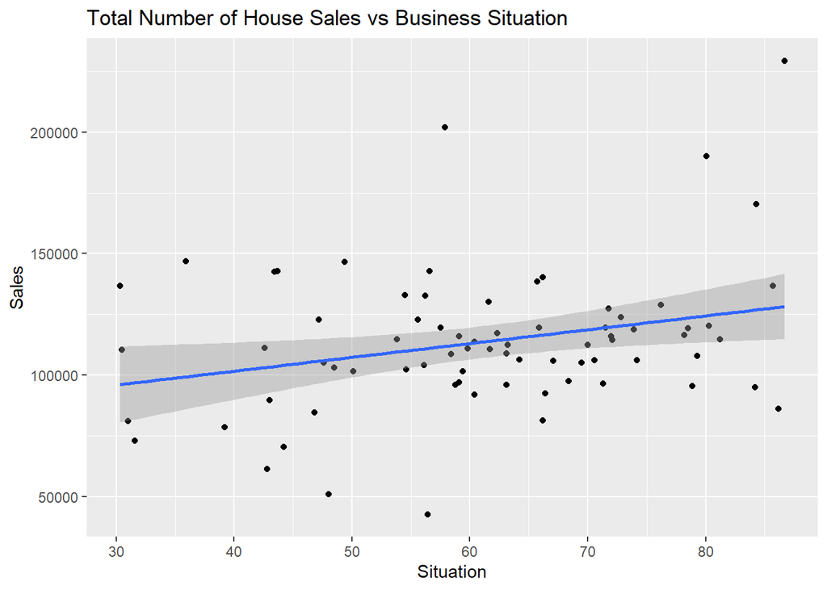

```r
survey1<-read_excel("C:/Users/User/Desktop/ie360/business.xlsx")
ggplot(house,aes(x=survey1$sit,y=sales))+geom_point()+geom_smooth(method = lm)+labs(title = "Total Number of House Sales vs Business Situation ", y = "Sales", x = "Situation")
```

### Correlation between target variable and Business Situation

```r
cor(house$sales,survey1$sit)
```

```
## [1] 0.276816
```

### Adding Survey Data as a predictor

The survey question is ‘How do you expect the demand for your company’s services to (turnover) change over the next 3 months?’.The survey results will give us the turnover expectations for the next three months of the people who own the business .

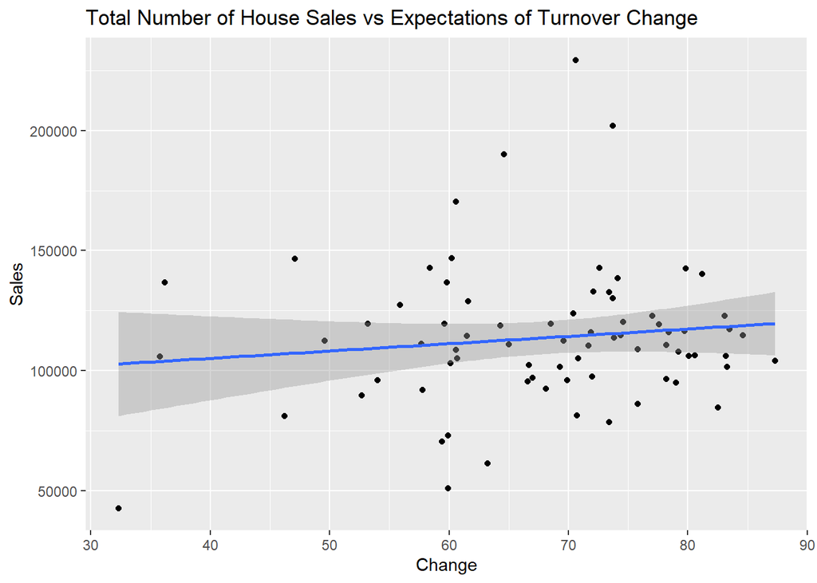

```r
survey2<-read_excel("C:/Users/User/Desktop/ie360/business2.xlsx")
ggplot(house,aes(x=survey2$sit,y=sales))+geom_point()+geom_smooth(method = lm)+labs(title = "Total Number of House Sales vs Expectations of Turnover Change ", y = "Sales", x = "Change")
```

### Correlation between target variable and Expectations of Turnover Change

```r
cor(house$sales,survey2$sit)
```

```
## [1] 0.12209
```

```r
house[,sur1:=survey1$sit]
house[,sur2:=survey2$sit]
house_reg6=lm(sales~mon+prob+altın+sur1+sur2+faiz,house)
summary(house_reg6)
```

```
##
## Call:
## lm(formula = sales ~ mon + prob + altın + sur1 + sur2 + faiz,
##     data = house)
##
## Residuals:
##    Min     1Q Median     3Q    Max
## -51722 -12335    686   9865  49675
##
## Coefficients:
##              Estimate Std. Error t value Pr(>|t|)
## (Intercept)  94008.46   49787.38   1.888  0.06400 .
## monAra       40906.63   12004.64   3.408  0.00120 **
## monEki       13893.54   11808.72   1.177  0.24418
## monEyl       11855.75   11627.89   1.020  0.31215
## monHaz       -2134.31   11549.26  -0.185  0.85403
## monKas        3378.42   11614.73   0.291  0.77219
## monMar        7397.79   11353.51   0.652  0.51724
## monMay       -9802.05   11754.57  -0.834  0.40776
## monNis        1954.88   12334.06   0.158  0.87462
## monOca      -20826.47   11290.35  -1.845  0.07020 .
## monŞub       -7745.60   11511.24  -0.673  0.50370
## monTem        4649.97   11531.31   0.403  0.68825
## prob         -3629.48     845.64  -4.292 6.81e-05 ***
## altın          248.14      41.07   6.041 1.17e-07 ***
## sur1           421.13     211.66   1.990  0.05135 .
## sur2          1130.09     334.64   3.377  0.00131 **
## faiz          -588.42     691.57  -0.851  0.39835
## ---
## Signif. codes:  0 '***' 0.001 '**' 0.01 '*' 0.05 '.' 0.1 ' ' 1
##
## Residual standard error: 19900 on 58 degrees of freedom
## Multiple R-squared:  0.6423, Adjusted R-squared:  0.5436
## F-statistic: 6.509 on 16 and 58 DF,  p-value: 4.865e-08
```

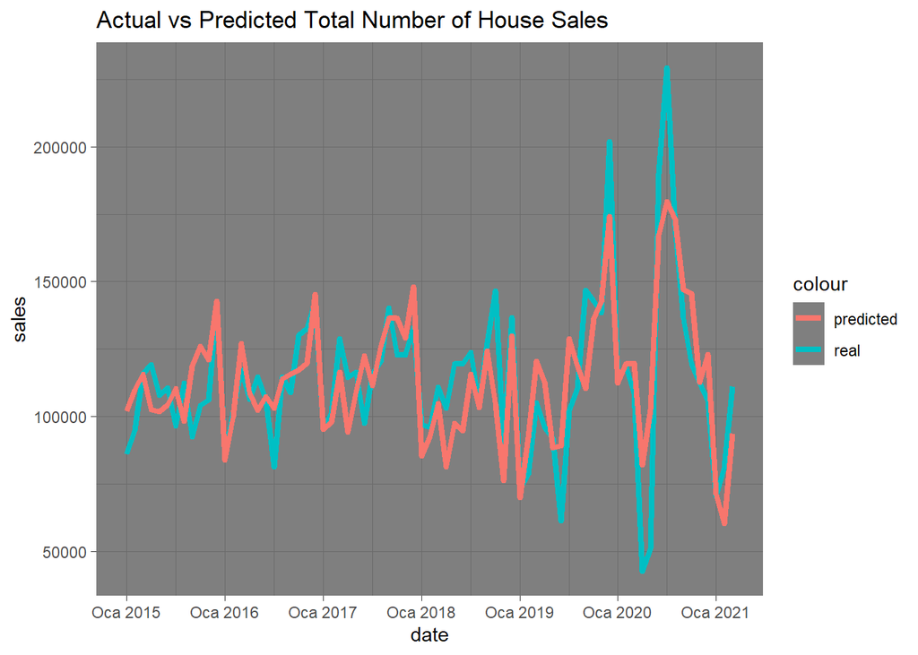

```r
house[,predictedvalues:=predict(house_reg6,house)]
ggplot(house,aes(x=date))+geom_line(aes(y=sales,color='real'),size=1.5)+geom_line(aes(y=predictedvalues,color='predicted'),size=1.5)+ theme_dark()+labs(title = "Actual vs Predicted Total Number of House Sales")
```

### Adding Housing Unit Price in Turkey as a predictor

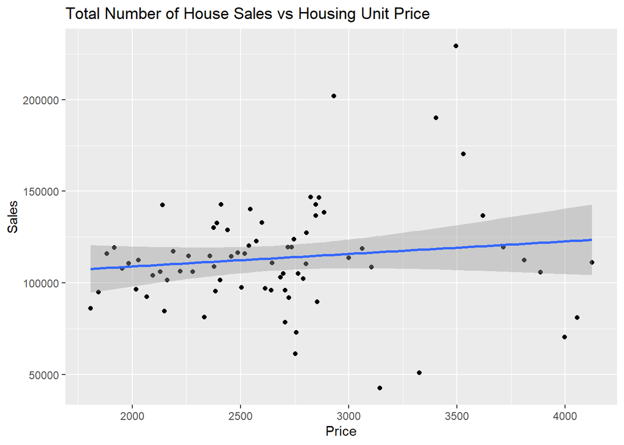

```r
housing<-read_excel("C:/Users/User/Desktop/ie360/HousingUnitPrice.xlsx")
ggplot(house,aes(x=housing$price,y=sales))+geom_point()+geom_smooth(method = lm)+labs(title = "Total Number of House Sales vs Housing Unit Price ", y = "Sales", x = "Price")
```

### Correlation between target variable and Housing Unit Price

```r
cor(house$sales,housing$price)
```

```
## [1] 0.1263502
```

```r
house[,unitprice:=housing$price]
house_reg7=lm(sales~mon+prob+altın+sur1+sur2+faiz+unitprice,house)
summary(house_reg7)
```

```
##
## Call:
## lm(formula = sales ~ mon + prob + altın + sur1 + sur2 + faiz +
##     unitprice, data = house)
##
## Residuals:
##    Min     1Q Median     3Q    Max
## -46081  -9415   -542  10431  50266
##
## Coefficients:
##              Estimate Std. Error t value Pr(>|t|)
## (Intercept)  23521.45   56205.74   0.418  0.67716
## monAra       39712.83   11554.01   3.437  0.00110 **
## monEki       14227.33   11355.71   1.253  0.21537
## monEyl       12513.14   11184.35   1.119  0.26791
## monHaz       -2675.45   11107.66  -0.241  0.81052
## monKas        1497.14   11195.94   0.134  0.89409
## monMar        6615.48   10922.02   0.606  0.54712
## monMay       -8673.90   11312.60  -0.767  0.44640
## monNis        5912.51   11974.69   0.494  0.62338
## monOca      -20677.03   10856.58  -1.905  0.06189 .
## monŞub       -7545.75   11069.12  -0.682  0.49819
## monTem        3462.51   11099.20   0.312  0.75621
## prob         -4236.66     851.79  -4.974 6.37e-06 ***
## altın          112.80      68.97   1.636  0.10743
## sur1           552.87     210.83   2.622  0.01118 *
## sur2          1293.61     328.95   3.933  0.00023 ***
## faiz          -561.94     665.08  -0.845  0.40169
## unitprice       37.95      15.85   2.394  0.02000 *
## ---
## Signif. codes:  0 '***' 0.001 '**' 0.01 '*' 0.05 '.' 0.1 ' ' 1
##
## Residual standard error: 19130 on 57 degrees of freedom
## Multiple R-squared:  0.675,  Adjusted R-squared:  0.578
## F-statistic: 6.962 on 17 and 57 DF,  p-value: 1.189e-08
```

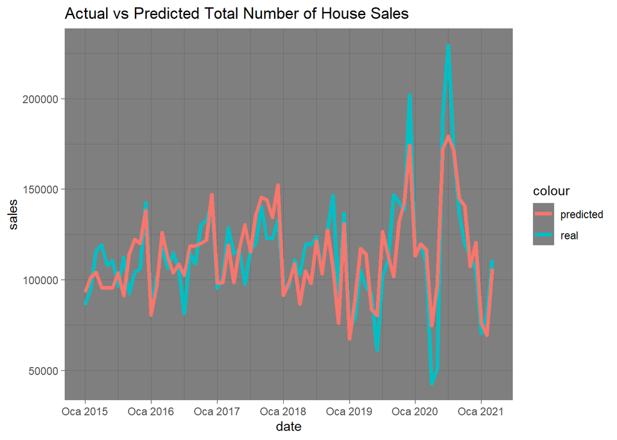

```r
house[,predictedvalues2:=predict(house_reg7,house)]
ggplot(house,aes(x=date))+geom_line(aes(y=sales,color='real'),size=1.5)+geom_line(aes(y=predictedvalues2,color='predicted'),size=1.5)+ theme_dark()+labs(title = "Actual vs Predicted Total Number of House Sales")
```

```r
house[Date=="2016-07",coup := 1]
house[is.na(coup) == T,coup := 0]
house[Date=="2020-04" | Date =="2020-05",Corona_starting_effect := 1]
house[is.na(Corona_starting_effect) == T,Corona_starting_effect := 0]
house[Date=="2020-06" | Date =="2020-07" | Date =="2020-08",Corona_ongoing_effect := 1]
house[is.na(Corona_ongoing_effect) == T,Corona_ongoing_effect := 0]
```

After the addition of the period of coup attempt and corona effects to model, Model is improved significantly and is good enough to make predictions for next month. At the beginning of the pandemic, it was thought to be an epidemic that would pass in a short time, so people did not change their long-term plans in life.Therefore, the virus has reduced number of house sales in two months after its first appearance in March in Turkey. By June, the number of cases and deaths of the epidemic reached high levels, and people understood that the epidemic would take a long time.When people realized that the epidemic would continue for a long time, they changed their long-term life plans.Among these long-term life plans, including the housing plan and also due to the distance measures of the epidemic, people started to buy detached houses.Of course, this increased the number of house sales tremendously in June, July and August.

```r
house_reg8=lm(sales~mon+prob+altın+sur1+sur2+faiz+unitprice+as.factor(coup)+as.factor(Corona_starting_effect)+as.factor(Corona_ongoing_effect),house)
summary(house_reg8)
```

```
##
## Call:
## lm(formula = sales ~ mon + prob + altın + sur1 + sur2 + faiz +
##     unitprice + as.factor(coup) + as.factor(Corona_starting_effect) +
##     as.factor(Corona_ongoing_effect), data = house)
##
## Residuals:
##    Min     1Q Median     3Q    Max
## -29167  -6453   -525   6058  42582
##
## Coefficients:
##                                     Estimate Std. Error t value Pr(>|t|)
## (Intercept)                        126265.47   47614.84   2.652 0.010488 *
## monAra                              38699.68    8933.79   4.332 6.47e-05 ***
## monEki                              19682.09    8872.46   2.218 0.030757 *
## monEyl                              16425.59    8758.92   1.875 0.066163 .
## monHaz                              -5493.36    8553.05  -0.642 0.523416
## monKas                               7954.92    8744.57   0.910 0.367024
## monMar                               8442.47    8428.59   1.002 0.320982
## monMay                               5507.66    9025.79   0.610 0.544280
## monNis                               7799.23    9274.06   0.841 0.404072
## monOca                             -17317.91    8405.06  -2.060 0.044191 *
## monŞub                              -7420.72    8521.13  -0.871 0.387685
## monTem                               8256.24    8947.44   0.923 0.360243
## prob                                -2580.10     751.91  -3.431 0.001159 **
## altın                                  52.97      60.85   0.871 0.387842
## sur1                                   82.54     178.60   0.462 0.645838
## sur2                                  383.85     288.54   1.330 0.188999
## faiz                                -1534.87     555.57  -2.763 0.007821 **
## unitprice                              20.05      12.60   1.592 0.117328
## as.factor(coup)1                   -27041.74   16361.10  -1.653 0.104173
## as.factor(Corona_starting_effect)1 -63571.96   13593.41  -4.677 1.99e-05 ***
## as.factor(Corona_ongoing_effect)1   54728.14   13636.68   4.013 0.000186 ***
## ---
## Signif. codes:  0 '***' 0.001 '**' 0.01 '*' 0.05 '.' 0.1 ' ' 1
##
## Residual standard error: 14690 on 54 degrees of freedom
## Multiple R-squared:  0.8185, Adjusted R-squared:  0.7513
## F-statistic: 12.18 on 20 and 54 DF,  p-value: 1.626e-13
```

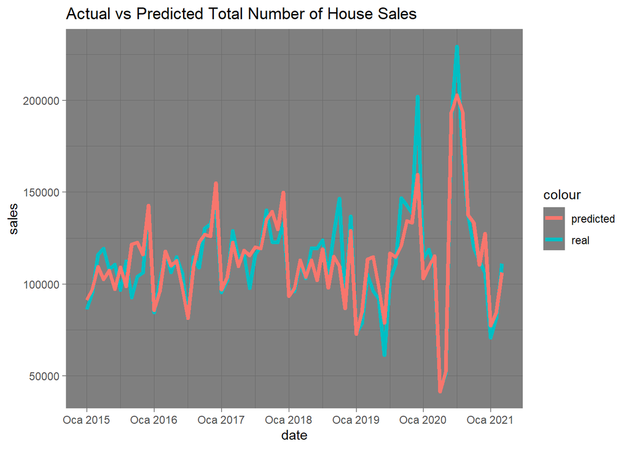

```r
house[,predictedvalues3:=predict(house_reg8,house)]
ggplot(house,aes(x=date))+geom_line(aes(y=sales,color='real'),size=1.5)+geom_line(aes(y=predictedvalues3,color='predicted'),size=1.5)+ theme_dark()+labs(title = "Actual vs Predicted Total Number of House Sales")
```

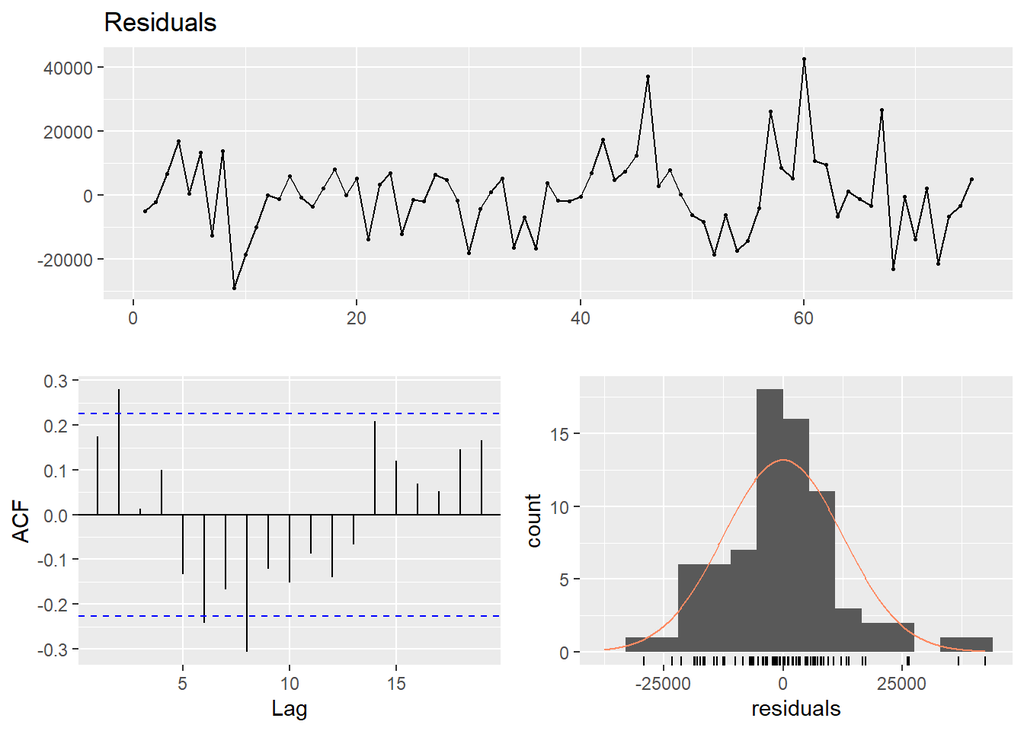

```r
checkresiduals(house_reg8$residuals)
```

## Prediction of April 2021 Value

```r
predict(house_reg8,data.frame(mon="Nis",prob=48.13,altın=464.33,sur1=70.5,sur2=55.5,faiz=18.13,unitprice=4123.2,coup=0,Corona_starting_effect=0,Corona_ongoing_effect=0))
```

```
##        1
## 116445.7
```

## Conclusion

In this study, a statistically acceptable model that is able to predict monthly total house sales in Turkey with minimum residual error ,maximum Adjusted R-squared and minimum p-value was obtained.With our fitted value, we predicted that our sales will be 116445.7 .